# Uber Analysis 2021-2022 report

Joy Omondi

2022-06-09

This is a comprehensive report on the Uber 2021-2022 data analysis.

### loading the necessary packages

```r
Jan2021 <- read.csv("Jan 2021.csv",skip = 5,header = TRUE)
Feb2021 <- read.csv("Feb 2021.csv",skip = 5,header = TRUE)
Mar2021 <- read.csv("Mar 2021.csv",skip = 5,header = TRUE)
Apr2021 <- read.csv("Apr 2021.csv",skip = 5,header = TRUE)
May2021 <- read.csv("May 2021.csv",skip = 5,header = TRUE)
June2021 <- read.csv("Jun 2021.csv",skip = 5,header = TRUE)
July2021 <- read.csv("Jul 2021.csv",skip = 5,header = TRUE)
```

#Binding the loaded data

```r
MyUberData <-rbind(Feb2021,Mar2021,Apr2021,May2021,June2021,July2021)
```

#reading in the remaining 2021 and 2022 data

```r
AugustApril <-
  read.csv("uber_AugApril22.csv",header = TRUE)%>%
   mutate("Request Time" = strptime(Transaction.timestamp..UTC., format = "%m/%d/%Y %H:%M"),
         "Date Requested" = as.IDate(`Request Time`),
         DayofWeek = weekdays(`Date Requested`),
         "Time Requested" = format(strptime(`Request.Time..Local.`,"%I:%M %p"),
                                   format = "%H:%M"),
         Year = as.numeric(format(`Date Requested`, "%Y")),
         Months = factor(months(as.Date(`Date Requested`)),
                         levels = month.name),
         Employee.Name = paste(First.name,Surname))%>%
    dplyr::select(-c(1,3,4,7,8,9,10,11,16,20,21,24,25,26,29,30,31,32,33,34,35,36))%>%
  rename(Total.Amount = Transaction.amount.in.KES..incl..taxes.)
```

#### data cleaning for the different datasets

```r
New.Data <-
  MyUberData[-c(1,3,4,7,8,9,10,11,16,20,21,24,25,26,29,30,31,32,33,34,35,36)]%>%
  mutate("Request Time" = strptime(Transaction.timestamp..UTC., format = "%Y-%m-%d %H:%M"),
         "Date Requested" = as.IDate(`Request Time`),
        DayofWeek = weekdays(`Date Requested`),
        Year = as.numeric(format(`Date Requested`, "%Y")),
        Months = factor(months(as.Date(`Date Requested`)),
                        levels = month.name),
        Employee.Name = paste(First.name,Surname))%>%
  rename(Total.Amount = Transaction.amount.in.KES..incl..taxes.)
```

```r
Jan_DataCleaning <-
  (Jan2021[,-1])%>%#,AugustApril[,-1]
    dplyr::select(-c(2,3,6,7,8,9,10,15,19,20,23,24,25,28,29,30,31,32,33,34,35))%>%
    mutate("Request Time" = strptime(Transaction.timestamp..UTC., format = "%d/%m/%Y %H:%M"),
           "Date Requested" = as.IDate(`Request Time`),
           DayofWeek = weekdays(`Date Requested`),
           Year = as.numeric(format(`Date Requested`, "%Y")),
           Months = factor(months(as.Date(`Date Requested`)),
                           levels = month.name),
           Employee.Name = paste(First.name,Surname))%>%
    rename(Total.Amount = Transaction.amount.in.KES..incl..taxes.)
```

#combining the two datasets into one

```r
AnalysisData <- bind_rows(New.Data,AugustApril,Jan_DataCleaning)
```

##Creating empty vectors for the columns we want to create for Payments and Transactions so that we able to see both the payments and transactions in one analysis

```r
Transaction = vector(length = 1341)
Payments = vector(length = 1341)

for (i in 1:NROW(AnalysisData$Total.Amount)) {
  if(AnalysisData$Total.Amount[i] <= 0){
    Payments[i] <- AnalysisData$Total.Amount[i]
  }else{(AnalysisData$Total.Amount[i] >= 0)
    Transaction[i] <-  AnalysisData$Total.Amount[i]
  }
}


AnalysisData$Transaction <- Transaction
AnalysisData$Payments <- Payments
```

##Analysis of Transactions and payments

```r
Analysis_Expense <-
  AnalysisData%>%
    dplyr::select(Months,Year,Payments,Transaction)%>%
    distinct(Months,Year,Payments,Transaction)%>%
    group_by(Months,Year)%>%
    summarise(TotalPayments = sum(Payments),
              TotalTransaction = sum(Transaction))%>%
    mutate(Difference = (TotalPayments +TotalTransaction))
```

##Analysis of Monthly Expenditure

```r
MonthlyExpenses <-
  AnalysisData%>%
    filter(Total.Amount >= 0)%>%
    dplyr::select(Months,Total.Amount,Year,Transaction.type)%>%
    distinct(Months,Total.Amount,Year,Transaction.type)%>%
    group_by(Months,Year)%>%
    summarise(MonthlyExpenditure = sum(Total.Amount))%>%
    dplyr::select(Year,MonthlyExpenditure)
```

#### the general spending in the first quarter of 2022 is more than that of 2021

#### Visualization using a Histogram

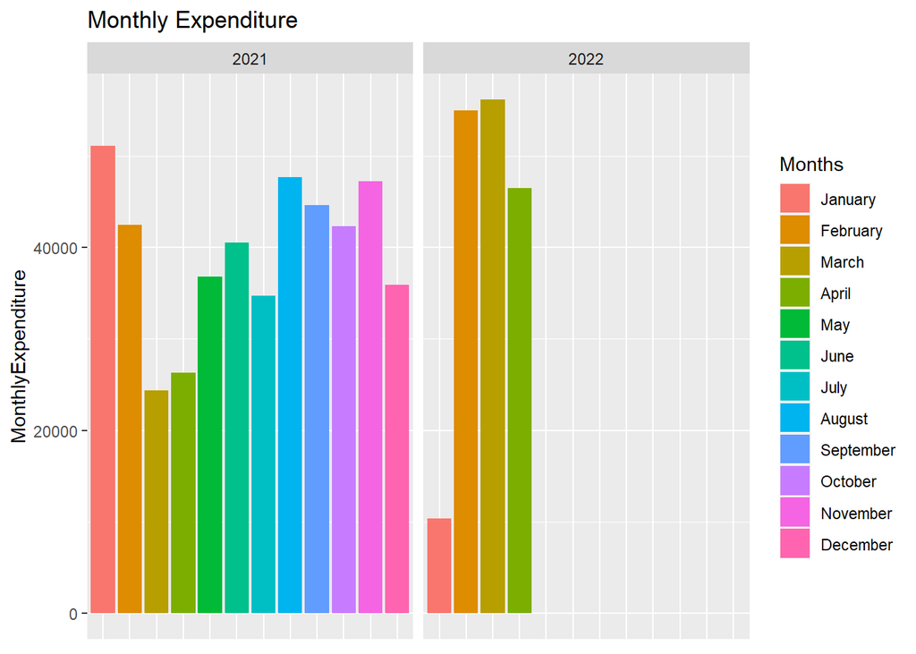

```r
  ggplot(MonthlyExpenses,aes(fill = Months,x = Months,y = MonthlyExpenditure))+
    geom_histogram(position = "dodge",stat = "identity")+
    facet_grid(.~Year)+
    ggtitle("Monthly Expenditure")+
    theme(axis.title.x=element_blank(),
        axis.text.x=element_blank(),
        axis.ticks.x=element_blank())
```

#importing departmental data

```r
  Employee_Data <- read.csv("EmployeeNames.csv", header = TRUE)
  AnalysisData$Employee.Name
```

[output not shown]

[output cut: 432 more lines]

```r
  codes = Employee_Data$Employee.Name
  Department <- vector(mode="character", length=nrow(AnalysisData))

  for (i in 1:nrow(AnalysisData)) {
    idx = match(AnalysisData$Employee.Name[i], codes)
    Department[i] <- Employee_Data$Department[idx]
  }
```

##Departmental analysis

```r
DeptAnalysis <-
  cbind(AnalysisData,Department)%>%
    #filter(Total.Amount >= 0)%>%
    dplyr::select(Department,Transaction,Months,Year,Transaction.type)%>%
    group_by(Department,Months,Year,Transaction.type)%>%
    filter(Year == 2022)%>%
    summarise(DeptTotals = sum(Transaction))
DeptAnalysis$Department[which(is.na(DeptAnalysis$Department))] <- "Service&Technology"
```

##Visualizing the Departments data

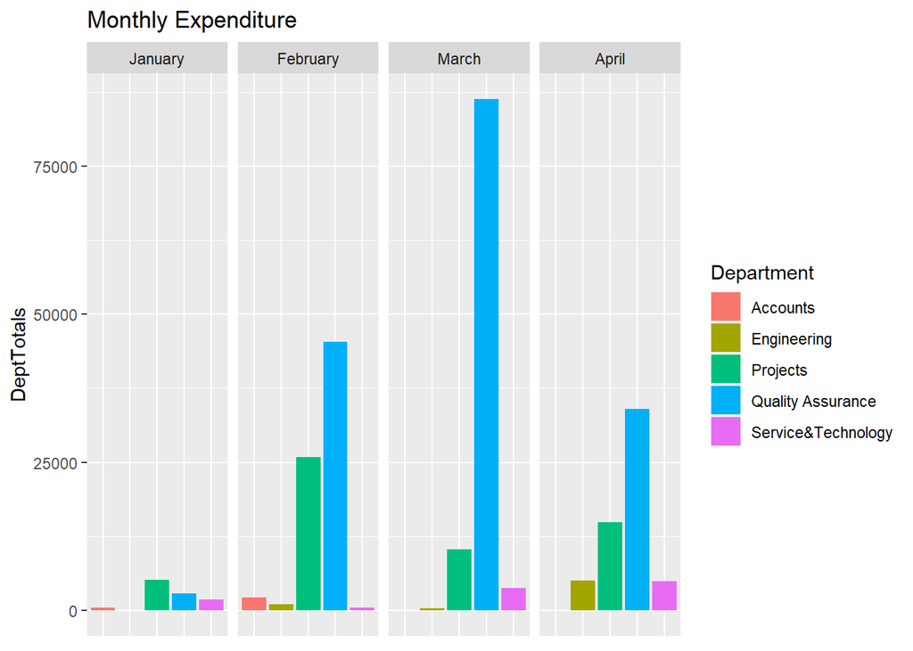

```r
ggplot(DeptAnalysis,aes(fill = Department,x = Department,y = DeptTotals))+
  geom_histogram(position = "dodge",stat = "identity")+
  facet_grid(.~Months)+
  ggtitle("Monthly Expenditure")+
  theme(axis.title.x=element_blank(),
        axis.text.x=element_blank(),
        axis.ticks.x=element_blank())
```

##Analysis of frequency of order

```r
frequencyOfOrder <-
  AnalysisData%>%
    filter(Total.Amount >= 0)%>%
    dplyr::select(Months,Year,Transaction.type, Employee.Name)%>%
    group_by(Months, Year)%>%
    count()%>%
    rename(freq = n)
```

#Visualizing the number of trips in each month

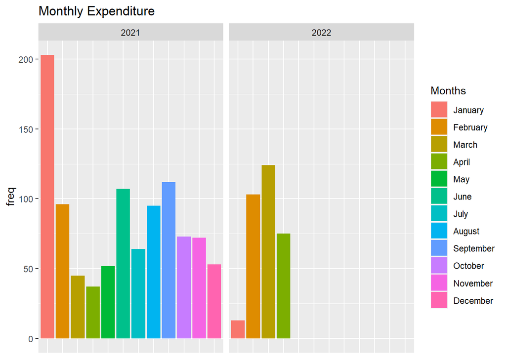

```r
  ggplot(frequencyOfOrder,aes(fill = Months,x = Months,y = freq))+
    geom_histogram(position = "dodge",stat = "identity")+
    facet_grid(.~Year)+
    ggtitle("Monthly Expenditure")+
    theme(axis.title.x=element_blank(),
          axis.text.x=element_blank(),
          axis.ticks.x=element_blank())
```

##There seems to be a decrease in the number of trips from the first quarter of 2021 compared to the first quarter of the 2022 despite the increase in amount spent.

###Correlation between distance duration and amount paid

```r
  Correlation <-
    AnalysisData%>%
      mutate(Distance = as.numeric(Distance..mi.),
             Duration = as.numeric(Duration..mins.))%>%
      filter(Year == "2022")%>%
      dplyr::select(Duration,Distance,Total.Amount)%>%
      na.omit()
cor(Correlation)
```

```
##               Duration  Distance Total.Amount
## Duration     1.0000000 0.6986620    0.8084328
## Distance     0.6986620 1.0000000    0.8468522
## Total.Amount 0.8084328 0.8468522    1.0000000
```